# Identify_Customer_Segments

### Prerequsite - Upgrade Scikit Learn

The current workspace has scikit-learn v0.19.1 installed. However, you can upgrade scikit-learn to 0.24.x. and use this [OneHotEncoder](https://scikit-learn.org/0.21/modules/generated/sklearn.preprocessing.OneHotEncoder.html) library.

```python
# import sklearn
# print('The scikit-learn version is {}.'.format(sklearn.__version__))
```

```python
# import os
# os.environ['PATH'] = f"{os.environ['PATH']}:/root/.local/bin"
```

Restart the Kernel.

```python
# !python -m pip install --upgrade scikit-learn
# import sklearn
# print('The scikit-learn version is {}.'.format(sklearn.__version__))
```

```python
# Now you can import and use OneHotEncoder
from sklearn.preprocessing import OneHotEncoder
# your code goes here
```

```python
# Similarly, should you need any other package, they can install it as:
# !python -m pip install 'tensorflow-tensorboard<0.2.0,>=0.1.0'
```

```python
# !pip install -U pandas
```

# Project: Identify Customer Segments

In this project, you will apply unsupervised learning techniques to identify segments of the population that form the core customer base for a mail-order sales company in Germany. These segments can then be used to direct marketing campaigns towards audiences that will have the highest expected rate of returns. The data that you will use has been provided by our partners at Bertelsmann Arvato Analytics, and represents a real-life data science task.

This notebook will help you complete this task by providing a framework within which you will perform your analysis steps. In each step of the project, you will see some text describing the subtask that you will perform, followed by one or more code cells for you to complete your work. **Feel free to add additional code and markdown cells as you go along so that you can explore everything in precise chunks.** The code cells provided in the base template will outline only the major tasks, and will usually not be enough to cover all of the minor tasks that comprise it.

It should be noted that while there will be precise guidelines on how you should handle certain tasks in the project, there will also be places where an exact specification is not provided. **There will be times in the project where you will need to make and justify your own decisions on how to treat the data.** These are places where there may not be only one way to handle the data. In real-life tasks, there may be many valid ways to approach an analysis task. One of the most important things you can do is clearly document your approach so that other scientists can understand the decisions you've made.

At the end of most sections, there will be a Markdown cell labeled **Discussion**. In these cells, you will report your findings for the completed section, as well as document the decisions that you made in your approach to each subtask. **Your project will be evaluated not just on the code used to complete the tasks outlined, but also your communication about your observations and conclusions at each stage.**

```python
# import libraries here; add more as necessary

import warnings
warnings.filterwarnings('ignore')

import numpy as np
import pandas as pd
import matplotlib.pyplot as plt
import seaborn as sns

# magic word for producing visualizations in notebook
%matplotlib inline

'''
Import note: The classroom currently uses sklearn version 0.19.
If you need to use an imputer, it is available in sklearn.preprocessing.Imputer,
instead of sklearn.impute as in newer versions of sklearn.
'''
pd.options.display.max_rows = None
pd.options.display.max_columns = None
```

### Step 0: Load the Data

Each row of the demographics files represents a single person, but also includes information outside of individuals, including information about their household, building, and neighborhood. You will use this information to cluster the general population into groups with similar demographic properties. Then, you will see how the people in the customers dataset fit into those created clusters. The hope here is that certain clusters are over-represented in the customers data, as compared to the general population; those over-represented clusters will be assumed to be part of the core userbase. This information can then be used for further applications, such as targeting for a marketing campaign.

To start off with, load in the demographics data for the general population into a pandas DataFrame, and do the same for the feature attributes summary. Note for all of the `.csv` data files in this project: they're semicolon (`;`) delimited, so you'll need an additional argument in your [`read_csv()`](https://pandas.pydata.org/pandas-docs/stable/generated/pandas.read_csv.html) call to read in the data properly. Also, considering the size of the main dataset, it may take some time for it to load completely.

Once the dataset is loaded, it's recommended that you take a little bit of time just browsing the general structure of the dataset and feature summary file. You'll be getting deep into the innards of the cleaning in the first major step of the project, so gaining some general familiarity can help you get your bearings.

```python
# Load in the general demographics data.
gen_demo = pd.read_csv('Udacity_AZDIAS_Subset.csv', sep=';')
# Load in the feature summary file.
feat_sum = pd.read_csv('AZDIAS_Feature_Summary.csv', sep=';')
```

```python
# Check the structure of the data after it's loaded (e.g. print the number of
# rows and columns, print the first few rows).
print(gen_demo.shape)
gen_demo.head()
```

```
(891221, 85)
```

|  | AGER_TYP | ALTERSKATEGORIE_GROB | ANREDE_KZ | CJT_GESAMTTYP | FINANZ_MINIMALIST | FINANZ_SPARER | FINANZ_VORSORGER | FINANZ_ANLEGER | FINANZ_UNAUFFAELLIGER | FINANZ_HAUSBAUER | FINANZTYP | GEBURTSJAHR | GFK_URLAUBERTYP | GREEN_AVANTGARDE | HEALTH_TYP | LP_LEBENSPHASE_FEIN | LP_LEBENSPHASE_GROB | LP_FAMILIE_FEIN | LP_FAMILIE_GROB | LP_STATUS_FEIN | LP_STATUS_GROB | NATIONALITAET_KZ | PRAEGENDE_JUGENDJAHRE | RETOURTYP_BK_S | SEMIO_SOZ | SEMIO_FAM | SEMIO_REL | SEMIO_MAT | SEMIO_VERT | … |
| --- | --- | --- | --- | --- | --- | --- | --- | --- | --- | --- | --- | --- | --- | --- | --- | --- | --- | --- | --- | --- | --- | --- | --- | --- | --- | --- | --- | --- | --- | --- |
| 0 | -1 | 2 | 1 | 2.0 | 3 | 4 | 3 | 5 | 5 | 3 | 4 | 0 | 10.0 | 0 | -1 | 15.0 | 4.0 | 2.0 | 2.0 | 1.0 | 1.0 | 0 | 0 | 5.0 | 2 | 6 | 7 | 5 | 1 | … |
| 1 | -1 | 1 | 2 | 5.0 | 1 | 5 | 2 | 5 | 4 | 5 | 1 | 1996 | 10.0 | 0 | 3 | 21.0 | 6.0 | 5.0 | 3.0 | 2.0 | 1.0 | 1 | 14 | 1.0 | 5 | 4 | 4 | 3 | 1 | … |
| 2 | -1 | 3 | 2 | 3.0 | 1 | 4 | 1 | 2 | 3 | 5 | 1 | 1979 | 10.0 | 1 | 3 | 3.0 | 1.0 | 1.0 | 1.0 | 3.0 | 2.0 | 1 | 15 | 3.0 | 4 | 1 | 3 | 3 | 4 | … |
| 3 | 2 | 4 | 2 | 2.0 | 4 | 2 | 5 | 2 | 1 | 2 | 6 | 1957 | 1.0 | 0 | 2 | 0.0 | 0.0 | 0.0 | 0.0 | 9.0 | 4.0 | 1 | 8 | 2.0 | 5 | 1 | 2 | 1 | 4 | … |
| 4 | -1 | 3 | 1 | 5.0 | 4 | 3 | 4 | 1 | 3 | 2 | 5 | 1963 | 5.0 | 0 | 3 | 32.0 | 10.0 | 10.0 | 5.0 | 3.0 | 2.0 | 1 | 8 | 5.0 | 6 | 4 | 4 | 2 | 7 | … |

```python
# Check for null values and feature dtypes
gen_demo.info()
```

```
<class 'pandas.DataFrame'>
RangeIndex: 891221 entries, 0 to 891220
Data columns (total 85 columns):
 #   Column                 Non-Null Count   Dtype
---  ------                 --------------   -----
 0   AGER_TYP               891221 non-null  int64
 1   ALTERSKATEGORIE_GROB   891221 non-null  int64
 2   ANREDE_KZ              891221 non-null  int64
 3   CJT_GESAMTTYP          886367 non-null  float64
 4   FINANZ_MINIMALIST      891221 non-null  int64
 5   FINANZ_SPARER          891221 non-null  int64
 6   FINANZ_VORSORGER       891221 non-null  int64
 7   FINANZ_ANLEGER         891221 non-null  int64
 8   FINANZ_UNAUFFAELLIGER  891221 non-null  int64
 9   FINANZ_HAUSBAUER       891221 non-null  int64
```

[output cut: 77 more lines]

> **Tip**: Add additional cells to keep everything in reasonably-sized chunks! Keyboard shortcut `esc --> a` (press escape to enter command mode, then press the 'A' key) adds a new cell before the active cell, and `esc --> b` adds a new cell after the active cell. If you need to convert an active cell to a markdown cell, use `esc --> m` and to convert to a code cell, use `esc --> y`.

## Step 1: Preprocessing

### Step 1.1: Assess Missing Data

The feature summary file contains a summary of properties for each demographics data column. You will use this file to help you make cleaning decisions during this stage of the project. First of all, you should assess the demographics data in terms of missing data. Pay attention to the following points as you perform your analysis, and take notes on what you observe. Make sure that you fill in the **Discussion** cell with your findings and decisions at the end of each step that has one!

#### Step 1.1.1: Convert Missing Value Codes to NaNs

The fourth column of the feature attributes summary (loaded in above as `feat_info`) documents the codes from the data dictionary that indicate missing or unknown data. While the file encodes this as a list (e.g. `[-1,0]`), this will get read in as a string object. You'll need to do a little bit of parsing to make use of it to identify and clean the data. Convert data that matches a 'missing' or 'unknown' value code into a numpy NaN value. You might want to see how much data takes on a 'missing' or 'unknown' code, and how much data is naturally missing, as a point of interest.

**As one more reminder, you are encouraged to add additional cells to break up your analysis into manageable chunks.**

```python
# Identify missing or unknown data values and convert them to NaNs.
feat_sum.head()
```

|  | attribute | information_level | type | missing_or_unknown |
| --- | --- | --- | --- | --- |
| 0 | AGER_TYP | person | categorical | [-1,0] |
| 1 | ALTERSKATEGORIE_GROB | person | ordinal | [-1,0,9] |
| 2 | ANREDE_KZ | person | categorical | [-1,0] |
| 3 | CJT_GESAMTTYP | person | categorical | [0] |
| 4 | FINANZ_MINIMALIST | person | ordinal | [-1] |

> As stated in the instructions, the `missing_or_unknown` column is in the form of strings, not python lists. The following cell parses this string to output each value in the column to its own column in a new DataFrame. In other words, a column with "[-1,0]" outputs to three columns with "-1", "0", and None. The final step replaces that None value with `np.nan`. Importanrly for later, these values are still strings, rather than numeric.

```python
# Parse missing_or_unknown column into three columns, one per value
feat_na = feat_sum['missing_or_unknown'].str.strip(to_strip='[]').str.split(pat=',', expand=True).replace({None: np.nan})
```

```python
feat_na.head()
```

|  | 0 | 1 | 2 |
| --- | --- | --- | --- |
| 0 | -1 | 0 | NaN |
| 1 | -1 | 0 | 9 |
| 2 | -1 | 0 | NaN |
| 3 | 0 | NaN | NaN |
| 4 | -1 | NaN | NaN |

```python
# Add new DataFrame to original feature summary DataFrame
feat_sum[['missing_or_unknown_1', 'missing_or_unknown_2', 'missing_or_unknown_3']] = feat_na
```

```python
# Remove original 'missing_or_unknown' column; it will no longer be needed
feat_sum.drop('missing_or_unknown', axis=1, inplace=True)
```

```python
# Confirm change
feat_sum.head()
```

|  | attribute | information_level | type | missing_or_unknown_1 | missing_or_unknown_2 | missing_or_unknown_3 |
| --- | --- | --- | --- | --- | --- | --- |
| 0 | AGER_TYP | person | categorical | -1 | 0 | NaN |
| 1 | ALTERSKATEGORIE_GROB | person | ordinal | -1 | 0 | 9 |
| 2 | ANREDE_KZ | person | categorical | -1 | 0 | NaN |
| 3 | CJT_GESAMTTYP | person | categorical | 0 | NaN | NaN |
| 4 | FINANZ_MINIMALIST | person | ordinal | -1 | NaN | NaN |

```python
feat_sum['missing_or_unknown_1'].unique()
```

```
<StringArray>
['-1', '0', '', 'XX']
Length: 4, dtype: str
```

> As stated earlier, the `missing_or_unknown` values are still strings, not numeric. Not all values can be converted to numeric, as shown in the above cell. As such, we cannot cast the entire column as one singular data type. It would maybe be possible to cast the demographics df as string, but it contains NA values, which can be a hassle to deal with when casting. Instead, we can just try to cast each value as we come across it as int, float, or str. Using try-except blocks, we can simply ignore possible errors and brute force our way through.

```python
# Iterate over attributes in feature summary DataFrame; for each missing value indicator, replace that value in general demographics
# DataFrame with np.nan
for att in feat_sum['attribute']:
    na_vals = list(feat_sum.query(f'attribute == "{att}"')[['missing_or_unknown_1', 'missing_or_unknown_2',
                                           'missing_or_unknown_3']].values.flatten())
    # Iterate over indicator; attempt to cast it as one of three dtypes; replace corresponding values in gen_demo with np.nan
    for val in na_vals:
        try:
            gen_demo[att] = gen_demo[att].replace(to_replace=int(val), value=np.nan)
        except:
            pass
        try:
            gen_demo[att] = gen_demo[att].replace(to_replace=float(val), value=np.nan)
        except:
            pass
        try:
#     print(gen_demo[str(att)].head())
            gen_demo[att] = gen_demo[att].replace(to_replace=str(val), value=np.nan)
        except:
            pass
#     print(replace_mask)

gen_demo.head()
```

|  | AGER_TYP | ALTERSKATEGORIE_GROB | ANREDE_KZ | CJT_GESAMTTYP | FINANZ_MINIMALIST | FINANZ_SPARER | FINANZ_VORSORGER | FINANZ_ANLEGER | FINANZ_UNAUFFAELLIGER | FINANZ_HAUSBAUER | FINANZTYP | GEBURTSJAHR | GFK_URLAUBERTYP | GREEN_AVANTGARDE | HEALTH_TYP | LP_LEBENSPHASE_FEIN | LP_LEBENSPHASE_GROB | LP_FAMILIE_FEIN | LP_FAMILIE_GROB | LP_STATUS_FEIN | LP_STATUS_GROB | NATIONALITAET_KZ | PRAEGENDE_JUGENDJAHRE | RETOURTYP_BK_S | SEMIO_SOZ | SEMIO_FAM | SEMIO_REL | SEMIO_MAT | SEMIO_VERT | … |
| --- | --- | --- | --- | --- | --- | --- | --- | --- | --- | --- | --- | --- | --- | --- | --- | --- | --- | --- | --- | --- | --- | --- | --- | --- | --- | --- | --- | --- | --- | --- |
| 0 | NaN | 2.0 | 1 | 2.0 | 3 | 4 | 3 | 5 | 5 | 3 | 4 | NaN | 10.0 | 0 | NaN | 15.0 | 4.0 | 2.0 | 2.0 | 1.0 | 1.0 | NaN | NaN | 5.0 | 2 | 6 | 7 | 5 | 1 | … |
| 1 | NaN | 1.0 | 2 | 5.0 | 1 | 5 | 2 | 5 | 4 | 5 | 1 | 1996.0 | 10.0 | 0 | 3.0 | 21.0 | 6.0 | 5.0 | 3.0 | 2.0 | 1.0 | 1.0 | 14.0 | 1.0 | 5 | 4 | 4 | 3 | 1 | … |
| 2 | NaN | 3.0 | 2 | 3.0 | 1 | 4 | 1 | 2 | 3 | 5 | 1 | 1979.0 | 10.0 | 1 | 3.0 | 3.0 | 1.0 | 1.0 | 1.0 | 3.0 | 2.0 | 1.0 | 15.0 | 3.0 | 4 | 1 | 3 | 3 | 4 | … |
| 3 | 2.0 | 4.0 | 2 | 2.0 | 4 | 2 | 5 | 2 | 1 | 2 | 6 | 1957.0 | 1.0 | 0 | 2.0 | NaN | NaN | NaN | NaN | 9.0 | 4.0 | 1.0 | 8.0 | 2.0 | 5 | 1 | 2 | 1 | 4 | … |
| 4 | NaN | 3.0 | 1 | 5.0 | 4 | 3 | 4 | 1 | 3 | 2 | 5 | 1963.0 | 5.0 | 0 | 3.0 | 32.0 | 10.0 | 10.0 | 5.0 | 3.0 | 2.0 | 1.0 | 8.0 | 5.0 | 6 | 4 | 4 | 2 | 7 | … |

#### Step 1.1.2: Assess Missing Data in Each Column

How much missing data is present in each column? There are a few columns that are outliers in terms of the proportion of values that are missing. You will want to use matplotlib's [`hist()`](https://matplotlib.org/api/_as_gen/matplotlib.pyplot.hist.html) function to visualize the distribution of missing value counts to find these columns. Identify and document these columns. While some of these columns might have justifications for keeping or re-encoding the data, for this project you should just remove them from the dataframe. (Feel free to make remarks about these outlier columns in the discussion, however!)

For the remaining features, are there any patterns in which columns have, or share, missing data?

```python
# Show number of null values for each column
gen_demo.isna().sum().sort_values(ascending=False)
```

```
TITEL_KZ                 889061
AGER_TYP                 685843
KK_KUNDENTYP             584612
KBA05_BAUMAX             476524
GEBURTSJAHR              392318
ALTER_HH                 310267
KKK                      158064
REGIOTYP                 158064
W_KEIT_KIND_HH           147988
KBA05_ANTG1              133324
KBA05_GBZ                133324
KBA05_ANTG2              133324
KBA05_ANTG3              133324
KBA05_ANTG4              133324
MOBI_REGIO               133324
PLZ8_ANTG2               116515
PLZ8_ANTG3               116515
PLZ8_BAUMAX              116515
PLZ8_ANTG4               116515
PLZ8_HHZ                 116515
PLZ8_GBZ                 116515
PLZ8_ANTG1               116515
SHOPPER_TYP              111196
HEALTH_TYP               111196
VERS_TYP                 111196
NATIONALITAET_KZ         108315
PRAEGENDE_JUGENDJAHRE    108164
KBA13_ANZAHL_PKW         105800
ANZ_HAUSHALTE_AKTIV       99611
CAMEO_DEU_2015            99352
CAMEO_INTL_2015           99352
CAMEO_DEUG_2015           99352
LP_LEBENSPHASE_FEIN       97632
ARBEIT                    97375
RELAT_AB                  97375
ORTSGR_KLS9               97274
ANZ_HH_TITEL              97008
LP_LEBENSPHASE_GROB       94572
EWDICHTE                  93740
INNENSTADT                93740
```

[output cut: 31 more lines]

```
SEMIO_KULT                    0
ZABEOTYP                      0
SEMIO_FAM                     0
SEMIO_REL                     0
SEMIO_MAT                     0
SEMIO_SOZ                     0
SEMIO_LUST                    0
SEMIO_ERL                     0
SEMIO_KAEM                    0
SEMIO_RAT                     0
SEMIO_KRIT                    0
SEMIO_DOM                     0
SEMIO_PFLICHT                 0
SEMIO_VERT                    0
dtype: int64
```

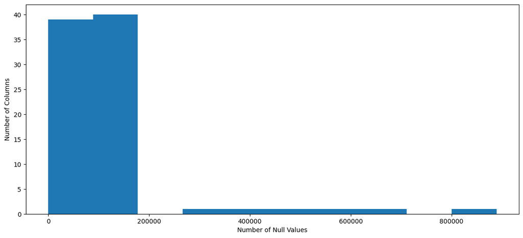

```python
# Perform an assessment of how much missing data there is in each column of the
# dataset.
plt.figure(figsize=(14,6))
plt.hist(gen_demo.isnull().sum())
plt.xlabel('Number of Null Values')
plt.ylabel('Number of Columns');
```

> Most features have fewer than 200,000 null values. In fact, all but 6 columns do.

```python
# Determine which columns have higher than 200,000 nulls
num_na_cols = 0
out_cols = []
for col in gen_demo:
    if gen_demo[str(col)].isna().sum() > 200000:
        num_na_cols += 1
        out_cols.append(col)
        print(col)
print(num_na_cols)
```

```
AGER_TYP
GEBURTSJAHR
TITEL_KZ
ALTER_HH
KK_KUNDENTYP
KBA05_BAUMAX
6
```

```python
# Remove the outlier columns from the dataset. (You'll perform other data
# engineering tasks such as re-encoding and imputation later.)

demo_nona = gen_demo.drop(out_cols, axis=1)
```

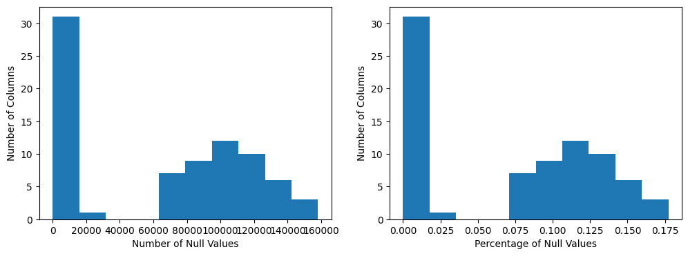

```python
# Plot new graph of null value counts, along with percentage of null values

plt.figure(figsize=(12,4))

plt.subplot(1,2,1)
plt.hist(demo_nona.isnull().sum())
plt.xlabel('Number of Null Values')
plt.ylabel('Number of Columns')

plt.subplot(1,2,2)
ax2 = plt.hist(demo_nona.isnull().mean())
plt.xlabel('Percentage of Null Values')
plt.ylabel('Number of Columns');
```

#### Step 1.1.3: Assess Missing Data in Each Row

Now, you'll perform a similar assessment for the rows of the dataset. How much data is missing in each row? As with the columns, you should see some groups of points that have a very different numbers of missing values. Divide the data into two subsets: one for data points that are above some threshold for missing values, and a second subset for points below that threshold.

In order to know what to do with the outlier rows, we should see if the distribution of data values on columns that are not missing data (or are missing very little data) are similar or different between the two groups. Select at least five of these columns and compare the distribution of values.

- You can use seaborn's [`countplot()`](https://seaborn.pydata.org/generated/seaborn.countplot.html) function to create a bar chart of code frequencies and matplotlib's [`subplot()`](https://matplotlib.org/api/_as_gen/matplotlib.pyplot.subplot.html) function to put bar charts for the two subplots side by side.
- To reduce repeated code, you might want to write a function that can perform this comparison, taking as one of its arguments a column to be compared.

Depending on what you observe in your comparison, this will have implications on how you approach your conclusions later in the analysis. If the distributions of non-missing features look similar between the data with many missing values and the data with few or no missing values, then we could argue that simply dropping those points from the analysis won't present a major issue. On the other hand, if the data with many missing values looks very different from the data with few or no missing values, then we should make a note on those data as special. We'll revisit these data later on. **Either way, you should continue your analysis for now using just the subset of the data with few or no missing values.**

```python
# How much data is missing in each row of the dataset?
(demo_nona.isnull().sum(axis=1)).head()
```

```
0    43
1     0
2     0
3     7
4     0
dtype: int64
```

```python
# Show summary statistics of nul values per row; 75% have 3 or fewer
(demo_nona.isnull().sum(axis=1)).describe()
```

```
count    891221.000000
mean          5.649894
std          13.234687
min           0.000000
25%           0.000000
50%           0.000000
75%           3.000000
max          49.000000
dtype: float64
```

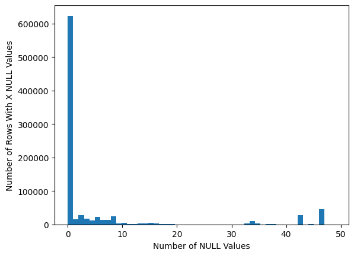

```python
# Plot number of nulls per row
plt.hist(demo_nona.isnull().sum(axis=1), bins=50)
plt.xlabel('Number of NULL Values')
plt.ylabel('Number of Rows With X NULL Values');
```

```python
# Write code to divide the data into two subsets based on the number of missing
# values in each row.
low_na = demo_nona[(demo_nona.isnull().sum(axis=1)) < 10]
high_na = demo_nona[(demo_nona.isnull().sum(axis=1)) >= 10]
low_na.head(1)
```

|  | ALTERSKATEGORIE_GROB | ANREDE_KZ | CJT_GESAMTTYP | FINANZ_MINIMALIST | FINANZ_SPARER | FINANZ_VORSORGER | FINANZ_ANLEGER | FINANZ_UNAUFFAELLIGER | FINANZ_HAUSBAUER | FINANZTYP | GFK_URLAUBERTYP | GREEN_AVANTGARDE | HEALTH_TYP | LP_LEBENSPHASE_FEIN | LP_LEBENSPHASE_GROB | LP_FAMILIE_FEIN | LP_FAMILIE_GROB | LP_STATUS_FEIN | LP_STATUS_GROB | NATIONALITAET_KZ | PRAEGENDE_JUGENDJAHRE | RETOURTYP_BK_S | SEMIO_SOZ | SEMIO_FAM | SEMIO_REL | SEMIO_MAT | SEMIO_VERT | SEMIO_LUST | SEMIO_ERL | … |
| --- | --- | --- | --- | --- | --- | --- | --- | --- | --- | --- | --- | --- | --- | --- | --- | --- | --- | --- | --- | --- | --- | --- | --- | --- | --- | --- | --- | --- | --- | --- |
| 1 | 1.0 | 2 | 5.0 | 1 | 5 | 2 | 5 | 4 | 5 | 1 | 10.0 | 0 | 3.0 | 21.0 | 6.0 | 5.0 | 3.0 | 2.0 | 1.0 | 1.0 | 14.0 | 1.0 | 5 | 4 | 4 | 3 | 1 | 2 | 2 | … |

```python
# Compare the distribution of values for at least five columns where there are
# no or few missing values, between the two subsets.
def compare_na(df1, df2):
    """
    Plot count of values from first 5 columns of df1, df2
    ACCEPTS:
        df1 - First pandas DataFrame
        df2 - Second pandas DataFrame
    RETURNS:
        None
    """
    cols = df1.columns.to_list()
    plt.figure(figsize=(16,8))

    # Do 5 times:
    for i in range(0,5):
        # Plot count of values in column i of first dataset
        plt.subplot(2,5,i+1)
        sns.countplot(x=df1[cols[i]], color='blue')
        plt.title(f'{cols[i]} low_na')

        # Plot count of values in column i of second dataset
        plt.subplot(2,5,i+6)
        sns.countplot(x=df2[cols[i]], color='orange')
        plt.title(f'{cols[i]} high_na')

        plt.subplots_adjust(wspace=0.5, hspace=0.5);
```

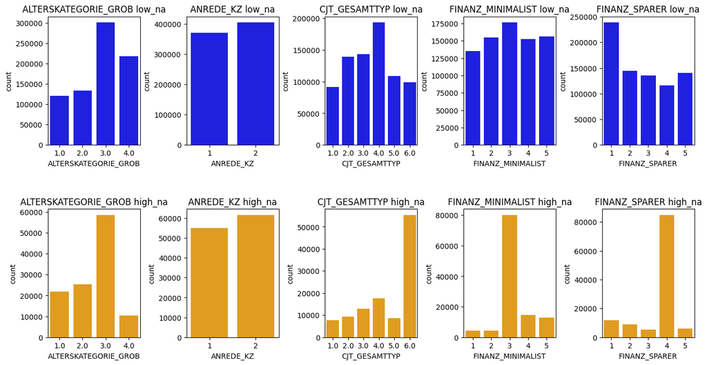

```python
compare_na(low_na, high_na)
```

#### Discussion 1.1.3: Assess Missing Data in Each Row

Most rows had fewer than 3 null vlaues. 10 nulls was chosen as the seperater, as it is the first major dropoff of after going from 0 to >0 nulls. The data in each column is fairly different between the two datasets.

### Step 1.2: Select and Re-Encode Features

Checking for missing data isn't the only way in which you can prepare a dataset for analysis. Since the unsupervised learning techniques to be used will only work on data that is encoded numerically, you need to make a few encoding changes or additional assumptions to be able to make progress. In addition, while almost all of the values in the dataset are encoded using numbers, not all of them represent numeric values. Check the third column of the feature summary (`feat_info`) for a summary of types of measurement.

- For numeric and interval data, these features can be kept without changes.
- Most of the variables in the dataset are ordinal in nature. While ordinal values may technically be non-linear in spacing, make the simplifying assumption that the ordinal variables can be treated as being interval in nature (that is, kept without any changes).
- Special handling may be necessary for the remaining two variable types: categorical, and 'mixed'.

In the first two parts of this sub-step, you will perform an investigation of the categorical and mixed-type features and make a decision on each of them, whether you will keep, drop, or re-encode each. Then, in the last part, you will create a new data frame with only the selected and engineered columns.

Data wrangling is often the trickiest part of the data analysis process, and there's a lot of it to be done here. But stick with it: once you're done with this step, you'll be ready to get to the machine learning parts of the project!

```python
feat_sum.head()
```

|  | attribute | information_level | type | missing_or_unknown_1 | missing_or_unknown_2 | missing_or_unknown_3 |
| --- | --- | --- | --- | --- | --- | --- |
| 0 | AGER_TYP | person | categorical | -1 | 0 | NaN |
| 1 | ALTERSKATEGORIE_GROB | person | ordinal | -1 | 0 | 9 |
| 2 | ANREDE_KZ | person | categorical | -1 | 0 | NaN |
| 3 | CJT_GESAMTTYP | person | categorical | 0 | NaN | NaN |
| 4 | FINANZ_MINIMALIST | person | ordinal | -1 | NaN | NaN |

```python
# How many features are there of each data type?
feat_sum['type'].value_counts()
```

```
type
ordinal        49
categorical    21
numeric         7
mixed           7
interval        1
Name: count, dtype: int64
```

#### Step 1.2.1: Re-Encode Categorical Features

For categorical data, you would ordinarily need to encode the levels as dummy variables. Depending on the number of categories, perform one of the following:

- For binary (two-level) categoricals that take numeric values, you can keep them without needing to do anything.
- There is one binary variable that takes on non-numeric values. For this one, you need to re-encode the values as numbers or create a dummy variable.
- For multi-level categoricals (three or more values), you can choose to encode the values using multiple dummy variables (e.g. via [OneHotEncoder](http://scikit-learn.org/stable/modules/generated/sklearn.preprocessing.OneHotEncoder.html)), or (to keep things straightforward) just drop them from the analysis. As always, document your choices in the Discussion section.

```python
# Assess categorical variables: which are binary, which are multi-level, and
# which one needs to be re-encoded?
list(feat_sum.query('type == "categorical"')['attribute'])
```

```
['AGER_TYP',
 'ANREDE_KZ',
 'CJT_GESAMTTYP',
 'FINANZTYP',
 'GFK_URLAUBERTYP',
 'GREEN_AVANTGARDE',
 'LP_FAMILIE_FEIN',
 'LP_FAMILIE_GROB',
 'LP_STATUS_FEIN',
 'LP_STATUS_GROB',
 'NATIONALITAET_KZ',
 'SHOPPER_TYP',
 'SOHO_KZ',
 'TITEL_KZ',
 'VERS_TYP',
 'ZABEOTYP',
 'KK_KUNDENTYP',
 'GEBAEUDETYP',
 'OST_WEST_KZ',
 'CAMEO_DEUG_2015',
 'CAMEO_DEU_2015']
```

```python
# Create new DataFrame which will be used for one-hot encoding
low_na_dummy = low_na.copy()

# For each feature that is listed as "categorical", one-hot encode if not binary
for att in list(feat_sum.query('type == "categorical"')['attribute']):
    encode_list = []

    if att in list(low_na_dummy.columns):
        unique_vals = low_na_dummy[att].unique()

        # print(f'{att}: {unique_vals}\n')
        if len(unique_vals) - min(low_na_dummy[att].isnull().sum(), 1) > 2:
            for val in unique_vals:
                if f'{att}_{val}' != f'{att}_nan':
                    encode_list.append(f'{att}_{val}')
            # print(encode_list)

            low_na_dummy[encode_list] = pd.get_dummies(low_na[att], dummy_na=False, dtype='int')
            low_na_dummy = low_na_dummy.drop(att, axis=1)


low_na_dummy.head()
```

|  | ALTERSKATEGORIE_GROB | ANREDE_KZ | FINANZ_MINIMALIST | FINANZ_SPARER | FINANZ_VORSORGER | FINANZ_ANLEGER | FINANZ_UNAUFFAELLIGER | FINANZ_HAUSBAUER | GREEN_AVANTGARDE | HEALTH_TYP | LP_LEBENSPHASE_FEIN | LP_LEBENSPHASE_GROB | PRAEGENDE_JUGENDJAHRE | RETOURTYP_BK_S | SEMIO_SOZ | SEMIO_FAM | SEMIO_REL | SEMIO_MAT | SEMIO_VERT | SEMIO_LUST | SEMIO_ERL | SEMIO_KULT | SEMIO_RAT | SEMIO_KRIT | SEMIO_DOM | SEMIO_KAEM | SEMIO_PFLICHT | SEMIO_TRADV | SOHO_KZ | … |
| --- | --- | --- | --- | --- | --- | --- | --- | --- | --- | --- | --- | --- | --- | --- | --- | --- | --- | --- | --- | --- | --- | --- | --- | --- | --- | --- | --- | --- | --- | --- |
| 1 | 1.0 | 2 | 1 | 5 | 2 | 5 | 4 | 5 | 0 | 3.0 | 21.0 | 6.0 | 14.0 | 1.0 | 5 | 4 | 4 | 3 | 1 | 2 | 2 | 3 | 6 | 4 | 7 | 4 | 7 | 6 | 1.0 | … |
| 2 | 3.0 | 2 | 1 | 4 | 1 | 2 | 3 | 5 | 1 | 3.0 | 3.0 | 1.0 | 15.0 | 3.0 | 4 | 1 | 3 | 3 | 4 | 4 | 6 | 3 | 4 | 7 | 7 | 7 | 3 | 3 | 0.0 | … |
| 3 | 4.0 | 2 | 4 | 2 | 5 | 2 | 1 | 2 | 0 | 2.0 | NaN | NaN | 8.0 | 2.0 | 5 | 1 | 2 | 1 | 4 | 4 | 7 | 4 | 3 | 4 | 4 | 5 | 4 | 4 | 0.0 | … |
| 4 | 3.0 | 1 | 4 | 3 | 4 | 1 | 3 | 2 | 0 | 3.0 | 32.0 | 10.0 | 8.0 | 5.0 | 6 | 4 | 4 | 2 | 7 | 4 | 4 | 6 | 2 | 3 | 2 | 2 | 4 | 2 | 0.0 | … |
| 5 | 1.0 | 2 | 3 | 1 | 5 | 2 | 2 | 5 | 0 | 3.0 | 8.0 | 2.0 | 3.0 | 3.0 | 2 | 4 | 7 | 4 | 2 | 2 | 2 | 5 | 7 | 4 | 4 | 4 | 7 | 6 | 0.0 | … |

```python
# "OST_WEST_KZ" is binary, so it wasn't encoded by the earlier loop, but it needs to be in numeric format
low_na_dummy['OST_WEST_KZ'] = low_na_dummy['OST_WEST_KZ'].replace({'W': 0, 'O': 1})
```

```python
# Check the new dimensions of the dataset
low_na_dummy.shape
```

```
(774743, 194)
```

#### Discussion 1.2.1: Re-Encode Categorical Features

I kept as many features as possible, as they could all be easily encoded.

#### Step 1.2.2: Engineer Mixed-Type Features

There are a handful of features that are marked as "mixed" in the feature summary that require special treatment in order to be included in the analysis. There are two in particular that deserve attention; the handling of the rest are up to your own choices:

- "PRAEGENDE_JUGENDJAHRE" combines information on three dimensions: generation by decade, movement (mainstream vs. avantgarde), and nation (east vs. west). While there aren't enough levels to disentangle east from west, you should create two new variables to capture the other two dimensions: an interval-type variable for decade, and a binary variable for movement.
- "CAMEO_INTL_2015" combines information on two axes: wealth and life stage. Break up the two-digit codes by their 'tens'-place and 'ones'-place digits into two new ordinal variables (which, for the purposes of this project, is equivalent to just treating them as their raw numeric values).
- If you decide to keep or engineer new features around the other mixed-type features, make sure you note your steps in the Discussion section.

Be sure to check `Data_Dictionary.md` for the details needed to finish these tasks.

```python
# Check which features are "mixed"
feat_sum.query('type == "mixed"')['attribute']
```

```
15      LP_LEBENSPHASE_FEIN
16      LP_LEBENSPHASE_GROB
22    PRAEGENDE_JUGENDJAHRE
56                 WOHNLAGE
59          CAMEO_INTL_2015
64             KBA05_BAUMAX
79              PLZ8_BAUMAX
Name: attribute, dtype: str
```

```python
# Check data for mixed type attributes
mixed_list = list(feat_sum.query('type == "mixed"')['attribute'])
for att in mixed_list:
    if att not in list(low_na_dummy.columns):
        mixed_list.remove(att)
low_na_dummy[mixed_list].head()
```

|  | LP_LEBENSPHASE_FEIN | LP_LEBENSPHASE_GROB | PRAEGENDE_JUGENDJAHRE | WOHNLAGE | CAMEO_INTL_2015 | PLZ8_BAUMAX |
| --- | --- | --- | --- | --- | --- | --- |
| 1 | 21.0 | 6.0 | 14.0 | 4.0 | 51 | 1.0 |
| 2 | 3.0 | 1.0 | 15.0 | 2.0 | 24 | 1.0 |
| 3 | NaN | NaN | 8.0 | 7.0 | 12 | 1.0 |
| 4 | 32.0 | 10.0 | 8.0 | 3.0 | 43 | 2.0 |
| 5 | 8.0 | 2.0 | 3.0 | 7.0 | 54 | 1.0 |

```python
# Investigate "PRAEGENDE_JUGENDJAHRE" and engineer two new variables.
low_na_dummy['PRAEGENDE_JUGENDJAHRE'].value_counts()
```

```
PRAEGENDE_JUGENDJAHRE
14.0    177574
8.0     137903
10.0     83394
5.0      83112
3.0      52758
15.0     40803
11.0     34385
9.0      32939
6.0      25311
12.0     23925
4.0      20185
1.0      20106
2.0       7387
13.0      5520
7.0       3939
Name: count, dtype: int64
```

```python
# Map values in "PRAEGENDE_JUGENDJAHRE" to decade, movement (binary)
map_mask = {
    1: '1940,0',
    2: '1940,1',
    3: '1950,0',
    4: '1950,1',
    5: '1960,0',
    6: '1960,1',
    7: '1960,1',
    8: '1970,0',
    9: '1970,1',
    10: '1980,0',
    11: '1980,1',
    12: '1980,0',
    13: '1980,1',
    14: '1990,0',
    15: '1990,1'
    }

# Replace values in "PRAEGENDE_JUGENDJAHRE" to decade,movement string
low_na_dummy['PRAEGENDE_JUGENDJAHRE'] = low_na_dummy['PRAEGENDE_JUGENDJAHRE'].replace(map_mask)
low_na_dummy['PRAEGENDE_JUGENDJAHRE'].head()
```

```
1    1990,0
2    1990,1
3    1970,0
4    1970,0
5    1950,0
Name: PRAEGENDE_JUGENDJAHRE, dtype: object
```

```python
# Split "PRAEGENDE_JUGENDJAHRE" string by comma, remove original column
low_na_dummy[['Decade', 'Movement']] = low_na_dummy['PRAEGENDE_JUGENDJAHRE'].str.split(pat=',', expand=True)
low_na_dummy = low_na_dummy.drop('PRAEGENDE_JUGENDJAHRE', axis=1)
```

```python
low_na_dummy.head()
```

|  | ALTERSKATEGORIE_GROB | ANREDE_KZ | FINANZ_MINIMALIST | FINANZ_SPARER | FINANZ_VORSORGER | FINANZ_ANLEGER | FINANZ_UNAUFFAELLIGER | FINANZ_HAUSBAUER | GREEN_AVANTGARDE | HEALTH_TYP | LP_LEBENSPHASE_FEIN | LP_LEBENSPHASE_GROB | RETOURTYP_BK_S | SEMIO_SOZ | SEMIO_FAM | SEMIO_REL | SEMIO_MAT | SEMIO_VERT | SEMIO_LUST | SEMIO_ERL | SEMIO_KULT | SEMIO_RAT | SEMIO_KRIT | SEMIO_DOM | SEMIO_KAEM | SEMIO_PFLICHT | SEMIO_TRADV | SOHO_KZ | VERS_TYP | … |
| --- | --- | --- | --- | --- | --- | --- | --- | --- | --- | --- | --- | --- | --- | --- | --- | --- | --- | --- | --- | --- | --- | --- | --- | --- | --- | --- | --- | --- | --- | --- |
| 1 | 1.0 | 2 | 1 | 5 | 2 | 5 | 4 | 5 | 0 | 3.0 | 21.0 | 6.0 | 1.0 | 5 | 4 | 4 | 3 | 1 | 2 | 2 | 3 | 6 | 4 | 7 | 4 | 7 | 6 | 1.0 | 2.0 | … |
| 2 | 3.0 | 2 | 1 | 4 | 1 | 2 | 3 | 5 | 1 | 3.0 | 3.0 | 1.0 | 3.0 | 4 | 1 | 3 | 3 | 4 | 4 | 6 | 3 | 4 | 7 | 7 | 7 | 3 | 3 | 0.0 | 1.0 | … |
| 3 | 4.0 | 2 | 4 | 2 | 5 | 2 | 1 | 2 | 0 | 2.0 | NaN | NaN | 2.0 | 5 | 1 | 2 | 1 | 4 | 4 | 7 | 4 | 3 | 4 | 4 | 5 | 4 | 4 | 0.0 | 1.0 | … |
| 4 | 3.0 | 1 | 4 | 3 | 4 | 1 | 3 | 2 | 0 | 3.0 | 32.0 | 10.0 | 5.0 | 6 | 4 | 4 | 2 | 7 | 4 | 4 | 6 | 2 | 3 | 2 | 2 | 4 | 2 | 0.0 | 2.0 | … |
| 5 | 1.0 | 2 | 3 | 1 | 5 | 2 | 2 | 5 | 0 | 3.0 | 8.0 | 2.0 | 3.0 | 2 | 4 | 7 | 4 | 2 | 2 | 2 | 5 | 7 | 4 | 4 | 4 | 7 | 6 | 0.0 | 2.0 | … |

```python
# Investigate "CAMEO_INTL_2015" and engineer two new variables.
low_na_dummy['CAMEO_INTL_2015'].head()
```

```
1    51
2    24
3    12
4    43
5    54
Name: CAMEO_INTL_2015, dtype: str
```

```python
# Convert "CAMEO_INTL_2015" to wealth and life_stage
low_na_dummy['Wealth'] = np.floor(pd.to_numeric(low_na_dummy['CAMEO_INTL_2015']) / 10)
low_na_dummy['Life_Stage'] = pd.to_numeric(low_na_dummy['CAMEO_INTL_2015']) % 10
low_na_dummy = low_na_dummy.drop('CAMEO_INTL_2015', axis=1)
```

```python
low_na_dummy.head()
```

|  | ALTERSKATEGORIE_GROB | ANREDE_KZ | FINANZ_MINIMALIST | FINANZ_SPARER | FINANZ_VORSORGER | FINANZ_ANLEGER | FINANZ_UNAUFFAELLIGER | FINANZ_HAUSBAUER | GREEN_AVANTGARDE | HEALTH_TYP | LP_LEBENSPHASE_FEIN | LP_LEBENSPHASE_GROB | RETOURTYP_BK_S | SEMIO_SOZ | SEMIO_FAM | SEMIO_REL | SEMIO_MAT | SEMIO_VERT | SEMIO_LUST | SEMIO_ERL | SEMIO_KULT | SEMIO_RAT | SEMIO_KRIT | SEMIO_DOM | SEMIO_KAEM | SEMIO_PFLICHT | SEMIO_TRADV | SOHO_KZ | VERS_TYP | … |
| --- | --- | --- | --- | --- | --- | --- | --- | --- | --- | --- | --- | --- | --- | --- | --- | --- | --- | --- | --- | --- | --- | --- | --- | --- | --- | --- | --- | --- | --- | --- |
| 1 | 1.0 | 2 | 1 | 5 | 2 | 5 | 4 | 5 | 0 | 3.0 | 21.0 | 6.0 | 1.0 | 5 | 4 | 4 | 3 | 1 | 2 | 2 | 3 | 6 | 4 | 7 | 4 | 7 | 6 | 1.0 | 2.0 | … |
| 2 | 3.0 | 2 | 1 | 4 | 1 | 2 | 3 | 5 | 1 | 3.0 | 3.0 | 1.0 | 3.0 | 4 | 1 | 3 | 3 | 4 | 4 | 6 | 3 | 4 | 7 | 7 | 7 | 3 | 3 | 0.0 | 1.0 | … |
| 3 | 4.0 | 2 | 4 | 2 | 5 | 2 | 1 | 2 | 0 | 2.0 | NaN | NaN | 2.0 | 5 | 1 | 2 | 1 | 4 | 4 | 7 | 4 | 3 | 4 | 4 | 5 | 4 | 4 | 0.0 | 1.0 | … |
| 4 | 3.0 | 1 | 4 | 3 | 4 | 1 | 3 | 2 | 0 | 3.0 | 32.0 | 10.0 | 5.0 | 6 | 4 | 4 | 2 | 7 | 4 | 4 | 6 | 2 | 3 | 2 | 2 | 4 | 2 | 0.0 | 2.0 | … |
| 5 | 1.0 | 2 | 3 | 1 | 5 | 2 | 2 | 5 | 0 | 3.0 | 8.0 | 2.0 | 3.0 | 2 | 4 | 7 | 4 | 2 | 2 | 2 | 5 | 7 | 4 | 4 | 4 | 7 | 6 | 0.0 | 2.0 | … |

Save for "WOHNLAGE", each of these has information that other features also have. The "LEBENSPHASE" features have info contained in "CAMEO_INTL_2015", just at different granularities, and the "BAUMAX" features are part of sets ("PLZ8" and "KBA05") that, in total, contain essentially the same information. As such, "WOHNLAGE" will be re-engineered, and the others will be dropped.

```python
# Check values in "WOHNLAGE"
low_na_dummy['WOHNLAGE'].value_counts()
```

```
WOHNLAGE
3.0    244502
7.0    165983
4.0    133116
2.0     98105
5.0     72346
1.0     42859
8.0     14891
0.0      2941
Name: count, dtype: int64
```

```python
# Create replace-map for "WOHNLAGE"
wohn_map = {
    0.0: '0,0',
    1.0: '0,1',
    2.0: '0,2',
    3.0: '0,3',
    4.0: '0,4',
    5.0: '0,5',
    6.0: '0,6',
    7.0: '1,0',
    8.0: '1,0'
}

# Replace numeric values with comma separated strings; split strings into two columns
low_na_dummy['WOHNLAGE'] = low_na_dummy['WOHNLAGE'].replace(wohn_map)
low_na_dummy[['Rural', 'Neighborhood_Quality']] = (low_na_dummy['WOHNLAGE'].str.split(',', expand=True))
```

```python
# Drop original "WOHNLAGE" column
low_na_dummy = low_na_dummy.drop('WOHNLAGE', axis=1)
```

```python
# Drop other columns
drop_cols = ['LP_LEBENSPHASE_FEIN', 'LP_LEBENSPHASE_GROB', 'PLZ8_BAUMAX']
low_na_dummy = low_na_dummy.drop(drop_cols, axis=1)
low_na_dummy.head()
```

|  | ALTERSKATEGORIE_GROB | ANREDE_KZ | FINANZ_MINIMALIST | FINANZ_SPARER | FINANZ_VORSORGER | FINANZ_ANLEGER | FINANZ_UNAUFFAELLIGER | FINANZ_HAUSBAUER | GREEN_AVANTGARDE | HEALTH_TYP | RETOURTYP_BK_S | SEMIO_SOZ | SEMIO_FAM | SEMIO_REL | SEMIO_MAT | SEMIO_VERT | SEMIO_LUST | SEMIO_ERL | SEMIO_KULT | SEMIO_RAT | SEMIO_KRIT | SEMIO_DOM | SEMIO_KAEM | SEMIO_PFLICHT | SEMIO_TRADV | SOHO_KZ | VERS_TYP | ANZ_PERSONEN | ANZ_TITEL | … |
| --- | --- | --- | --- | --- | --- | --- | --- | --- | --- | --- | --- | --- | --- | --- | --- | --- | --- | --- | --- | --- | --- | --- | --- | --- | --- | --- | --- | --- | --- | --- |
| 1 | 1.0 | 2 | 1 | 5 | 2 | 5 | 4 | 5 | 0 | 3.0 | 1.0 | 5 | 4 | 4 | 3 | 1 | 2 | 2 | 3 | 6 | 4 | 7 | 4 | 7 | 6 | 1.0 | 2.0 | 2.0 | 0.0 | … |
| 2 | 3.0 | 2 | 1 | 4 | 1 | 2 | 3 | 5 | 1 | 3.0 | 3.0 | 4 | 1 | 3 | 3 | 4 | 4 | 6 | 3 | 4 | 7 | 7 | 7 | 3 | 3 | 0.0 | 1.0 | 1.0 | 0.0 | … |
| 3 | 4.0 | 2 | 4 | 2 | 5 | 2 | 1 | 2 | 0 | 2.0 | 2.0 | 5 | 1 | 2 | 1 | 4 | 4 | 7 | 4 | 3 | 4 | 4 | 5 | 4 | 4 | 0.0 | 1.0 | 0.0 | 0.0 | … |
| 4 | 3.0 | 1 | 4 | 3 | 4 | 1 | 3 | 2 | 0 | 3.0 | 5.0 | 6 | 4 | 4 | 2 | 7 | 4 | 4 | 6 | 2 | 3 | 2 | 2 | 4 | 2 | 0.0 | 2.0 | 4.0 | 0.0 | … |
| 5 | 1.0 | 2 | 3 | 1 | 5 | 2 | 2 | 5 | 0 | 3.0 | 3.0 | 2 | 4 | 7 | 4 | 2 | 2 | 2 | 5 | 7 | 4 | 4 | 4 | 7 | 6 | 0.0 | 2.0 | 1.0 | 0.0 | … |

#### Discussion 1.2.2: Engineer Mixed-Type Features

"WOHNLAGE" contained information about neighborhood quality, as well as whether or not the neighborhood was rural; it is the only feature that flags neighborhoods as rural, and it is also the only one that defines neighborhood quality. Because this feature contains unique information, it cannot be removed. As stated earlier, the "LEBENSPHASE" features contain information found in other features: life phase and wealth. This information can also be found in "CAMEO_INTL_2015", but in a slightly different, more annoying to parse way. Because this information is not unique, it can safely be dropped.

"PLZ8_BAUMAX" is similar, in that there are other "PLZ8" features, which contain mostly the same information. The only notable piece of info in "PLZ8_BAUMAX" is the "mainly business buildings" value, which can be determined by the other columns; if PLZ8_GBF (Number of buildings within the PLZ8 region) is high, while the other PLZ8 features are low, the buildings are likely mainly business, rather than family homes. Since this feature does not contain unique information, it can be dropped.

#### Step 1.2.3: Complete Feature Selection

In order to finish this step up, you need to make sure that your data frame now only has the columns that you want to keep. To summarize, the dataframe should consist of the following:

- All numeric, interval, and ordinal type columns from the original dataset.
- Binary categorical features (all numerically-encoded).
- Engineered features from other multi-level categorical features and mixed features.

Make sure that for any new columns that you have engineered, that you've excluded the original columns from the final dataset. Otherwise, their values will interfere with the analysis later on the project. For example, you should not keep "PRAEGENDE_JUGENDJAHRE", since its values won't be useful for the algorithm: only the values derived from it in the engineered features you created should be retained. As a reminder, your data should only be from **the subset with few or no missing values**.

> All of this was done in the previous section.

### Step 1.3: Create a Cleaning Function

Even though you've finished cleaning up the general population demographics data, it's important to look ahead to the future and realize that you'll need to perform the same cleaning steps on the customer demographics data. In this substep, complete the function below to execute the main feature selection, encoding, and re-engineering steps you performed above. Then, when it comes to looking at the customer data in Step 3, you can just run this function on that DataFrame to get the trimmed dataset in a single step.

```python
def clean_data(df, how='low'):
    """
    Perform feature trimming, re-encoding, and engineering for demographics
    data

    INPUT: Demographics DataFrame
    OUTPUT: Trimmed and cleaned demographics DataFrame
    """

    # Replace null indicators with np.nan; convert column to numeric
    for att in feat_sum['attribute']:
        na_vals = list(feat_sum.query(f'attribute == "{att}"')[['missing_or_unknown_1', 'missing_or_unknown_2',
                                           'missing_or_unknown_3']].values.flatten())
        for val in na_vals:
            try:
                df[att] = df[att].replace(to_replace=int(val), value=np.nan)
                df[att] = pd.to_numeric(df[att])
            except:
                pass
            try:
                df[att] = df[att].replace(to_replace=float(val), value=np.nan)
                df[att] = pd.to_numeric(df[att])
            except:
                pass
            try:
    #     print(df[str(att)].head())
                df[att] = df[att].replace(to_replace=str(val), value=np.nan)
                df[att] = pd.to_numeric(df[att])
            except:
                pass


    # Remove rows with more than 10 nulls; Removing columns based on nulls may result in a dataframe with different features than
    # the general demographics dataframe, which will result in issues later in the clustering section

    df = df[(df.isnull().sum(axis=1)) < 10]

    # One-hot encode data
    for att in list(feat_sum.query('type == "categorical"')['attribute']):
        encode_list = []

        if att in list(df.columns):
            unique_vals = df[att].unique()

            # print(f'{att}: {unique_vals}\n')
            if len(unique_vals) - min(df[att].isnull().sum(), 1) > 2:
                for val in unique_vals:
                    if f'{att}_{val}' != f'{att}_nan':
                        encode_list.append(f'{att}_{val}')

                df[encode_list] = pd.get_dummies(df[att], dummy_na=False, dtype='int')
                df = df.drop(att, axis=1)


    # Convert "OST_WEST_KZ" to numeric binary
    df['OST_WEST_KZ'] = df['OST_WEST_KZ'].replace({'W': 0, 'O': 1})

    # Re-engineer mixed features
    df['PRAEGENDE_JUGENDJAHRE'] = df['PRAEGENDE_JUGENDJAHRE'].replace(map_mask)
    df['WOHNLAGE'] = df['WOHNLAGE'].replace(wohn_map)

    df[['Decade', 'Movement']] = df['PRAEGENDE_JUGENDJAHRE'].str.split(pat=',', expand=True)
    df[['Rural', 'Neighborhood_Quality']] = df['WOHNLAGE'].str.split(',', expand=True)

    df['Wealth'] = pd.to_numeric(df['CAMEO_INTL_2015']) / 10
    df['Life_Stage'] = pd.to_numeric(df['CAMEO_INTL_2015']) % 10
    df['Wealth'] = np.floor(df['Wealth'])

    # If df contains features not in cleaned gen_demo df, remove feature
    for col in list(df.columns):
        if col not in list(low_na_dummy.columns):
            df = df.drop(col, axis=1)

    # The following code is done to cleaned gen_demo df in the next section 2.1

    # Convert None value in 'Movement' to np.nan
    df['Movement'] = df['Movement'].replace({None: np.nan})

    # Fill null values with previous value
    df = df.ffill()

    # In case a feature starts with a null value, also implement backfill
    df = df.bfill()

    # Ensure that all features are numeric
    for col in df.columns:
        df[col] = pd.to_numeric(df[col])

    # Certain vlaues do not exist in certain columns in the customer dataset. As such, the many one-hot encoded columns do not
    # exist. They need to be added to the customer df with a value of 0 or removed from the gen_demo df
    for col in list(low_na_dummy.columns):
        if col not in list(df.columns):
            df[col] = 0

    # Order columns to be the same order as cleaned gen_demo df
    df = df.loc[:, list(low_na_dummy.columns)]

    return df
```

## Step 2: Feature Transformation

### Step 2.1: Apply Feature Scaling

Before we apply dimensionality reduction techniques to the data, we need to perform feature scaling so that the principal component vectors are not influenced by the natural differences in scale for features. Starting from this part of the project, you'll want to keep an eye on the [API reference page for sklearn](http://scikit-learn.org/stable/modules/classes.html) to help you navigate to all of the classes and functions that you'll need. In this substep, you'll need to check the following:

- sklearn requires that data not have missing values in order for its estimators to work properly. So, before applying the scaler to your data, make sure that you've cleaned the DataFrame of the remaining missing values. This can be as simple as just removing all data points with missing data, or applying an [Imputer](https://scikit-learn.org/0.16/modules/generated/sklearn.preprocessing.Imputer.html) to replace all missing values. You might also try a more complicated procedure where you temporarily remove missing values in order to compute the scaling parameters before re-introducing those missing values and applying imputation. Think about how much missing data you have and what possible effects each approach might have on your analysis, and justify your decision in the discussion section below.
- For the actual scaling function, a [StandardScaler](http://scikit-learn.org/stable/modules/generated/sklearn.preprocessing.StandardScaler.html) instance is suggested, scaling each feature to mean 0 and standard deviation 1.
- For these classes, you can make use of the `.fit_transform()` method to both fit a procedure to the data as well as apply the transformation to the data at the same time. Don't forget to keep the fit sklearn objects handy, since you'll be applying them to the customer demographics data towards the end of the project.

```python
for col in low_na_dummy:
    print(f'{col}: {low_na_dummy[col].unique()}')
```

```
ALTERSKATEGORIE_GROB: [ 1.  3.  4.  2. nan]
ANREDE_KZ: [2 1]
FINANZ_MINIMALIST: [1 4 3 2 5]
FINANZ_SPARER: [5 4 2 3 1]
FINANZ_VORSORGER: [2 1 5 4 3]
FINANZ_ANLEGER: [5 2 1 4 3]
FINANZ_UNAUFFAELLIGER: [4 3 1 2 5]
FINANZ_HAUSBAUER: [5 2 3 4 1]
GREEN_AVANTGARDE: [0 1]
HEALTH_TYP: [ 3.  2.  1. nan]
RETOURTYP_BK_S: [1. 3. 2. 5. 4.]
SEMIO_SOZ: [5 4 6 2 7 3 1]
SEMIO_FAM: [4 1 5 7 2 6 3]
SEMIO_REL: [4 3 2 7 5 1 6]
SEMIO_MAT: [3 1 2 4 7 5 6]
SEMIO_VERT: [1 4 7 2 6 5 3]
SEMIO_LUST: [2 4 6 7 3 1 5]
SEMIO_ERL: [2 6 7 4 5 1 3]
SEMIO_KULT: [3 4 6 5 7 1 2]
SEMIO_RAT: [6 4 3 2 7 5 1]
SEMIO_KRIT: [4 7 3 1 5 6 2]
SEMIO_DOM: [7 4 2 1 5 6 3]
SEMIO_KAEM: [4 7 5 2 3 6 1]
SEMIO_PFLICHT: [7 3 4 5 1 6 2]
SEMIO_TRADV: [6 3 4 2 7 5 1]
SOHO_KZ: [1. 0.]
VERS_TYP: [ 2.  1. nan]
ANZ_PERSONEN: [ 2.  1.  0.  4.  3.  5.  6.  7.  8. 12.  9. 21. 10. 13. 11. 14. 45. 20.
 31. 37. 16. 22. 15. 23. 18. 35. 17. 40. 38.]
ANZ_TITEL: [0. 1. 2. 4. 3.]
HH_EINKOMMEN_SCORE: [6. 4. 1. 5. 3. 2.]
W_KEIT_KIND_HH: [ 3. nan  2.  6.  5.  4.  1.]
WOHNDAUER_2008: [9. 8. 3. 4. 5. 6. 2. 7. 1.]
ANZ_HAUSHALTE_AKTIV: [ 11.  10.   1.   3.   5.   4.   6.   2.   9.  nan  14.  13.   8.   7.
  44.  25.  36.  16. 272.  33.  15.  12.  22.  21.  20.  23.  18.  24.
  31.  39.  19.  30.  17.  29.  61.  54.  88.  49.  27.  60.  38.  34.
  48.  35.  62.  26.  45.  42.  28.  77.  47.  50. 236. 137.  43.  52.
  41.  76.  63.  32.  40.  37.  59.  53.  57. 118.  95.  78.  70.  46.
 185.  73.  67. 154.  80. 102.  92. 126.  94.  71.  66.  68.  81.  69.
 121. 258.  58.  86. 124.  85.  90. 128.  51.  72.  64.  56.  83. 150.
```

[output cut: 163 more lines]

```
CAMEO_DEU_2015_5B: [1 0]
CAMEO_DEU_2015_4D: [0 1]
CAMEO_DEU_2015_3A: [0 1]
CAMEO_DEU_2015_2B: [0 1]
CAMEO_DEU_2015_7E: [0 1]
CAMEO_DEU_2015_3B: [0 1]
CAMEO_DEU_2015_6F: [0 1]
CAMEO_DEU_2015_5F: [0 1]
CAMEO_DEU_2015_1C: [0 1]
Decade: ['1990' '1970' '1950' '1980' '1960' nan '1940']
Movement: ['0' '1' None]
Wealth: [ 5.  2.  1.  4.  3. nan]
Life_Stage: [ 1.  4.  2.  3.  5. nan]
Rural: ['0' '1']
Neighborhood_Quality: ['4' '2' '0' '3' '5' '1']
```

```python
# "Movement" feature contains value None rather than nan; replace None with np.nan
low_na_dummy['Movement'] = low_na_dummy['Movement'].replace({None: np.nan})
```

```python
# Fill nulls via propagation
low_na_dummy = low_na_dummy.ffill()
```

```python
# Ensure each feature is numeric
for col in low_na_dummy.columns:
    low_na_dummy[col] = pd.to_numeric(low_na_dummy[col])
```

```python
# Apply feature scaling to the general population demographics data.
from sklearn.preprocessing import StandardScaler
scaler = StandardScaler()
scaled_low_na = scaler.fit_transform(low_na_dummy)
```

### Discussion 2.1: Apply Feature Scaling

I chose to use propagation to fill nulls for two main reason: first, filling via mean or median could result in fractional values in some of the columns that are type float, but do not contain fractional values. This could potentially be solved be explicitly casing each column as int, but there's still another issue. Because I do not know the distribution of each column, mean, median, or mode could skew the distribution depending on how many null values there are. For example, a column with 40% 1's, 30% 0's, and 30% nulls, mean, median and mode would change the distribution to 70% 1's and 30% 0's; this heavily skews the data to one value, creating a new dataset that is not proportional to the original data.

### Step 2.2: Perform Dimensionality Reduction

On your scaled data, you are now ready to apply dimensionality reduction techniques.

- Use sklearn's [PCA](http://scikit-learn.org/stable/modules/generated/sklearn.decomposition.PCA.html) class to apply principal component analysis on the data, thus finding the vectors of maximal variance in the data. To start, you should not set any parameters (so all components are computed) or set a number of components that is at least half the number of features (so there's enough features to see the general trend in variability).
- Check out the ratio of variance explained by each principal component as well as the cumulative variance explained. Try plotting the cumulative or sequential values using matplotlib's [`plot()`](https://matplotlib.org/api/_as_gen/matplotlib.pyplot.plot.html) function. Based on what you find, select a value for the number of transformed features you'll retain for the clustering part of the project.
- Once you've made a choice for the number of components to keep, make sure you re-fit a PCA instance to perform the decided-on transformation.

```python
# Apply PCA to the data.
from sklearn.decomposition import PCA
pca = PCA(random_state=42)
X_pca = pca.fit_transform(scaled_low_na)
```

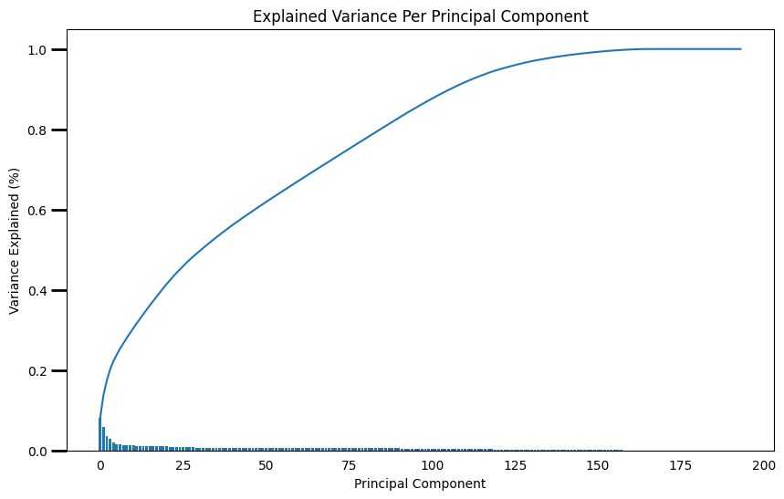

```python
# Investigate the variance accounted for by each principal component.

# Code from 'helper_functions.py' file from Udacity course
def scree_plot(pca):
    '''
    Creates a scree plot associated with the principal components

    INPUT: pca - the result of instantian of PCA in scikit learn

    OUTPUT:
            None
    '''
    num_components=len(pca.explained_variance_ratio_)
    ind = np.arange(num_components)
    vals = pca.explained_variance_ratio_

    plt.figure(figsize=(10, 6))
    ax = plt.subplot(111)
    cumvals = np.cumsum(vals)
    ax.bar(ind, vals)
    ax.plot(ind, cumvals)
    # # The following code writes the amount of variance explained by each component, which becomes very hard to read with this many
    # for i in range(num_components):
    #     ax.annotate(r"%s%%" % ((str(vals[i]*100)[:4])), (ind[i]+0.2, vals[i]), va="bottom", ha="center", fontsize=12)

    ax.xaxis.set_tick_params(width=0)
    ax.yaxis.set_tick_params(width=2, length=12)

    ax.set_xlabel("Principal Component")
    ax.set_ylabel("Variance Explained (%)")
    plt.title('Explained Variance Per Principal Component')


# Plot principle component variance
scree_plot(pca)
```

> 90 is selected, since 90 components appear to explain about 80% of the variance. This value is largely arbitrary; I wanted to reduce the components by at least half, and 80% of variance should be enough to reliably make predictions.

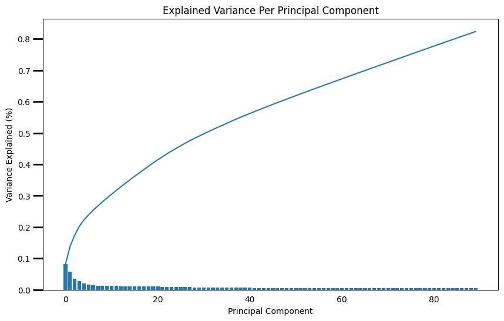

```python
# Re-apply PCA to the data while selecting for number of components to retain.
pca = PCA(n_components=90, random_state=42)
X_pca = pca.fit_transform(scaled_low_na)

scree_plot(pca)
```

### Discussion 2.2: Perform Dimensionality Reduction

I am keeping 90 components, explaining 80% of the variance. This should be enough for the results to be reliable, while cutting down on a significant number of components.

### Step 2.3: Interpret Principal Components

Now that we have our transformed principal components, it's a nice idea to check out the weight of each variable on the first few components to see if they can be interpreted in some fashion.

As a reminder, each principal component is a unit vector that points in the direction of highest variance (after accounting for the variance captured by earlier principal components). The further a weight is from zero, the more the principal component is in the direction of the corresponding feature. If two features have large weights of the same sign (both positive or both negative), then increases in one tend expect to be associated with increases in the other. To contrast, features with different signs can be expected to show a negative correlation: increases in one variable should result in a decrease in the other.

- To investigate the features, you should map each weight to their corresponding feature name, then sort the features according to weight. The most interesting features for each principal component, then, will be those at the beginning and end of the sorted list. Use the data dictionary document to help you understand these most prominent features, their relationships, and what a positive or negative value on the principal component might indicate.
- You should investigate and interpret feature associations from the first three principal components in this substep. To help facilitate this, you should write a function that you can call at any time to print the sorted list of feature weights, for the *i*-th principal component. This might come in handy in the next step of the project, when you interpret the tendencies of the discovered clusters.

```python
# Map weights for the first principal component to corresponding feature names
# and then print the linked values, sorted by weight.
# HINT: Try defining a function here or in a new cell that you can reuse in the
# other cells.

def pca_weight(pca, columns):
    """
    Creates dataframe mapping pca to feature names

    ACCPETS:
        pca - fitted pca
        columns - list of columns to map principle components to

    RETURNS:
        pandas DataFrame with components mapped to feature names
    """

    weights = pca.components_.tolist()
    percent_variance = pca.explained_variance_ratio_.tolist()

    weight_df = pd.DataFrame(weights, columns=columns)
    weight_df['percent_variance'] = percent_variance

    return weight_df
```

```python
weighted_gen = pca_weight(pca, low_na_dummy.columns)
weighted_gen.head()
```

|  | ALTERSKATEGORIE_GROB | ANREDE_KZ | FINANZ_MINIMALIST | FINANZ_SPARER | FINANZ_VORSORGER | FINANZ_ANLEGER | FINANZ_UNAUFFAELLIGER | FINANZ_HAUSBAUER | GREEN_AVANTGARDE | HEALTH_TYP | RETOURTYP_BK_S | SEMIO_SOZ | SEMIO_FAM | SEMIO_REL | SEMIO_MAT | SEMIO_VERT | SEMIO_LUST | SEMIO_ERL | SEMIO_KULT | SEMIO_RAT | SEMIO_KRIT | SEMIO_DOM | SEMIO_KAEM | SEMIO_PFLICHT | SEMIO_TRADV | SOHO_KZ | VERS_TYP | ANZ_PERSONEN | ANZ_TITEL | … |
| --- | --- | --- | --- | --- | --- | --- | --- | --- | --- | --- | --- | --- | --- | --- | --- | --- | --- | --- | --- | --- | --- | --- | --- | --- | --- | --- | --- | --- | --- | --- |
| 0 | 0.078772 | -0.013522 | 0.185150 | -0.108808 | 0.078406 | -0.047959 | -0.048261 | -0.146828 | 0.098510 | -0.023207 | 0.005793 | -0.023761 | -0.050133 | -0.074294 | -0.052479 | 0.040793 | 0.047761 | 0.044670 | -0.042783 | -0.065069 | -0.015571 | -0.025766 | -0.039460 | -0.078593 | -0.054971 | 0.002214 | -0.023136 | 0.081801 | 0.004610 | … |
| 1 | -0.234920 | -0.038570 | -0.094251 | 0.229678 | -0.220864 | 0.206548 | 0.215494 | -0.080119 | 0.001039 | 0.051696 | -0.157092 | 0.062771 | 0.134767 | 0.216818 | 0.131312 | 0.020622 | -0.164312 | -0.181538 | 0.166371 | 0.170367 | -0.073402 | -0.027226 | -0.056924 | 0.208369 | 0.209560 | 0.001739 | -0.022986 | 0.061507 | -0.007139 | … |
| 2 | -0.014444 | 0.340980 | -0.132878 | 0.054905 | -0.045990 | 0.154979 | 0.041984 | 0.068675 | -0.091088 | 0.005577 | -0.074401 | -0.255023 | -0.256576 | -0.112372 | -0.086406 | -0.316816 | -0.022275 | 0.205340 | -0.247458 | 0.151697 | 0.263433 | 0.275869 | 0.309461 | 0.023375 | 0.015748 | -0.000527 | -0.012889 | -0.014204 | -0.014758 | … |
| 3 | -0.025410 | 0.103023 | 0.000744 | 0.012939 | -0.017265 | -0.049176 | 0.063560 | -0.035769 | 0.284432 | -0.005819 | -0.012874 | -0.048104 | -0.077244 | -0.032779 | -0.019534 | -0.077645 | 0.007787 | 0.037548 | -0.077938 | 0.061972 | 0.053823 | 0.143331 | 0.132070 | 0.011194 | 0.033182 | 0.004437 | 0.012803 | 0.139099 | 0.034803 | … |
| 4 | -0.047977 | 0.025391 | -0.048421 | 0.025734 | -0.031043 | -0.029217 | 0.098131 | 0.039480 | 0.125397 | -0.003907 | -0.005168 | -0.010895 | 0.014679 | 0.032038 | 0.057498 | -0.026838 | -0.004249 | -0.036821 | -0.015953 | 0.051434 | 0.056760 | 0.027079 | -0.000027 | 0.031600 | 0.067307 | -0.005633 | -0.007145 | -0.289911 | 0.008994 | … |

```python
# Find the first 3 components; print the highest and smallest 5 values for each along with feature names
for i in range(3):
    print(f'{i+1}, lowest')
    print(weighted_gen.loc[i].sort_values()[:5], '\n')
    print(f'{i+1}, highest')
    print(weighted_gen.loc[i].sort_values(ascending=False)[:5], '\n')
    print('----------------------------\n')
```

```
1, lowest
LP_STATUS_GROB_1.0   -0.194460
Wealth               -0.183169
PLZ8_ANTG3           -0.182640
HH_EINKOMMEN_SCORE   -0.181494
PLZ8_ANTG4           -0.176268
Name: 0, dtype: float64

1, highest
MOBI_REGIO           0.201653
KBA05_ANTG1          0.187889
FINANZ_MINIMALIST    0.185150
PLZ8_ANTG1           0.181701
KBA05_GBZ            0.179563
Name: 0, dtype: float64

----------------------------

2, lowest
ALTERSKATEGORIE_GROB   -0.234920
FINANZ_VORSORGER       -0.220864
ZABEOTYP_4             -0.199351
SEMIO_ERL              -0.181538
SEMIO_LUST             -0.164312
Name: 1, dtype: float64

2, highest
Decade                   0.236018
FINANZ_SPARER            0.229678
SEMIO_REL                0.216818
FINANZ_UNAUFFAELLIGER    0.215494
SEMIO_TRADV              0.209560
Name: 1, dtype: float64

----------------------------

3, lowest
SEMIO_VERT    -0.316816
SEMIO_FAM     -0.256576
SEMIO_SOZ     -0.255023
SEMIO_KULT    -0.247458
FINANZTYP_4   -0.137352
Name: 2, dtype: float64

3, highest
ANREDE_KZ     0.340980
SEMIO_KAEM    0.309461
SEMIO_DOM     0.275869
SEMIO_KRIT    0.263433
SEMIO_ERL     0.205340
Name: 2, dtype: float64

----------------------------
```

### Discussion 2.3: Interpret Principal Components

The values, particularly the signs, indicate correlation. Within a component, as one positive feature increases, other positive features increase, while negative features decrease.

Similarly, in the second component, "Decade" and "FINANZ_SPARER" are positively related, indicating that indivuals from later decades, younger people, tend to save money more.

The others in component 1:

- LP_STATUS_GROB_1.0: Low income learners
- Wealth: 1 - Wealthy household, 5 - Poorer household
- PLZ8_ANTG3: Number of 6-10 family houses in the PLZ8 region; 0 - None, 3 - high share
- HH_EINKOMMEN_SCORE: Estimated household net income; 1 - highest income, 6 - very low income
- PLZ8_ANTG4: Number of 10+ family houses in the PLZ8 region; 0 - None, 2 - high share
- MOBI_REGIO: Movement patterns; 1 - very high movement, 6 - None
- KBA05_ANTG1: Number of 1-2 family houses in the microcell; 0 - None, 4 - high share
- FINANZ_MINIMALIST: Low financial interest
- PLZ8_ANTG1: Number of 1-2 family houses in the PLZ8 region; 0 - None, 4 - high share
- KBA05_GBZ: Number of buildings in the microcell; 0 - 1-2 buildings, 5 - >=23 buildings

## Step 3: Clustering

### Step 3.1: Apply Clustering to General Population

You've assessed and cleaned the demographics data, then scaled and transformed them. Now, it's time to see how the data clusters in the principal components space. In this substep, you will apply k-means clustering to the dataset and use the average within-cluster distances from each point to their assigned cluster's centroid to decide on a number of clusters to keep.

- Use sklearn's KMeans class to perform k-means clustering on the PCA-transformed data.
- Then, compute the average difference from each point to its assigned cluster's center. **Hint**: The KMeans object's `.score()` method might be useful here, but note that in sklearn, scores tend to be defined so that larger is better. Try applying it to a small, toy dataset, or use an internet search to help your understanding.
- Perform the above two steps for a number of different cluster counts. You can then see how the average distance decreases with an increasing number of clusters. However, each additional cluster provides a smaller net benefit. Use this fact to select a final number of clusters in which to group the data. **Warning**: because of the large size of the dataset, it can take a long time for the algorithm to resolve. The more clusters to fit, the longer the algorithm will take. You should test for cluster counts through at least 10 clusters to get the full picture, but you shouldn't need to test for a number of clusters above about 30.
- Once you've selected a final number of clusters to use, re-fit a KMeans instance to perform the clustering operation. Make sure that you also obtain the cluster assignments for the general demographics data, since you'll be using them in the final Step 3.3.

```python
from sklearn.cluster import KMeans
```

```python
cluster_scores = {}

# For each number of clusters, fit and score the model, add cluster count and score to dict
for i in range(1, 30, 3):
    kmeans = KMeans(n_clusters=i, random_state=42)
    model = kmeans.fit(X_pca)

    score = np.abs(model.score(X_pca))
    cluster_scores[i] = score

cluster_scores
```

```
{1: np.float64(123763126.92653175),
 4: np.float64(107132359.17821684),
 7: np.float64(102657127.83793923),
 10: np.float64(99192095.01665062),
 13: np.float64(97338476.07874255),
 16: np.float64(95860565.89246237),
 19: np.float64(93647558.65674359),
 22: np.float64(92383705.92711186),
 25: np.float64(90908978.46034229),
 28: np.float64(89746651.61027177)}
```

```python
# Convert cluster count-score dict to df
cluster_scores = pd.DataFrame.from_dict(cluster_scores, orient='index')
cluster_scores.head()
```

|  | 0 |
| --- | --- |
| 1 | 1.237631e+08 |
| 4 | 1.071324e+08 |
| 7 | 1.026571e+08 |
| 10 | 9.919210e+07 |
| 13 | 9.733848e+07 |

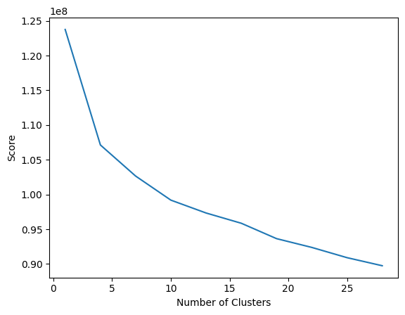

```python
# Investigate the change in within-cluster distance across number of clusters.
# HINT: Use matplotlib's plot function to visualize this relationship.
plt.plot(cluster_scores)
plt.xlabel('Number of Clusters')
plt.ylabel('Score');
```

> There is no clear optimal number of clusters; 10 is chosen.

```python
# Re-fit the k-means model with the selected number of clusters and obtain
# cluster predictions for the general population demographics data.
kmeans = KMeans(n_clusters=10, random_state=42)
general_model = kmeans.fit(X_pca)
general_predict = general_model.predict(X_pca)
```

### Step 3.2: Apply All Steps to the Customer Data

Now that you have clusters and cluster centers for the general population, it's time to see how the customer data maps on to those clusters. Take care to not confuse this for re-fitting all of the models to the customer data. Instead, you're going to use the fits from the general population to clean, transform, and cluster the customer data. In the last step of the project, you will interpret how the general population fits apply to the customer data.

- Don't forget when loading in the customers data, that it is semicolon (`;`) delimited.
- Apply the same feature wrangling, selection, and engineering steps to the customer demographics using the `clean_data()` function you created earlier. (You can assume that the customer demographics data has similar meaning behind missing data patterns as the general demographics data.)
- Use the sklearn objects from the general demographics data, and apply their transformations to the customers data. That is, you should not be using a `.fit()` or `.fit_transform()` method to re-fit the old objects, nor should you be creating new sklearn objects! Carry the data through the feature scaling, PCA, and clustering steps, obtaining cluster assignments for all of the data in the customer demographics data.

```python
# Load in the customer demographics data.
customers = pd.read_csv('Udacity_CUSTOMERS_Subset.csv', sep=';')
```

```python
customers.head()
```

|  | AGER_TYP | ALTERSKATEGORIE_GROB | ANREDE_KZ | CJT_GESAMTTYP | FINANZ_MINIMALIST | FINANZ_SPARER | FINANZ_VORSORGER | FINANZ_ANLEGER | FINANZ_UNAUFFAELLIGER | FINANZ_HAUSBAUER | FINANZTYP | GEBURTSJAHR | GFK_URLAUBERTYP | GREEN_AVANTGARDE | HEALTH_TYP | LP_LEBENSPHASE_FEIN | LP_LEBENSPHASE_GROB | LP_FAMILIE_FEIN | LP_FAMILIE_GROB | LP_STATUS_FEIN | LP_STATUS_GROB | NATIONALITAET_KZ | PRAEGENDE_JUGENDJAHRE | RETOURTYP_BK_S | SEMIO_SOZ | SEMIO_FAM | SEMIO_REL | SEMIO_MAT | SEMIO_VERT | … |
| --- | --- | --- | --- | --- | --- | --- | --- | --- | --- | --- | --- | --- | --- | --- | --- | --- | --- | --- | --- | --- | --- | --- | --- | --- | --- | --- | --- | --- | --- | --- |
| 0 | 2 | 4 | 1 | 5.0 | 5 | 1 | 5 | 1 | 2 | 2 | 2 | 0 | 4.0 | 1 | 1 | 20.0 | 5.0 | 2.0 | 2.0 | 10.0 | 5.0 | 1 | 4 | 5.0 | 6 | 5 | 2 | 6 | 6 | … |
| 1 | -1 | 4 | 1 | NaN | 5 | 1 | 5 | 1 | 3 | 2 | 2 | 0 | NaN | 0 | 1 | NaN | NaN | NaN | NaN | NaN | NaN | 1 | 0 | NaN | 3 | 6 | 2 | 6 | 7 | … |
| 2 | -1 | 4 | 2 | 2.0 | 5 | 1 | 5 | 1 | 4 | 4 | 2 | 0 | 3.0 | 1 | 2 | 13.0 | 3.0 | 1.0 | 1.0 | 10.0 | 5.0 | 1 | 4 | 5.0 | 2 | 2 | 1 | 3 | 3 | … |
| 3 | 1 | 4 | 1 | 2.0 | 5 | 1 | 5 | 2 | 1 | 2 | 6 | 0 | 10.0 | 0 | 2 | 0.0 | 0.0 | 0.0 | 0.0 | 9.0 | 4.0 | 1 | 1 | 3.0 | 6 | 5 | 3 | 4 | 7 | … |
| 4 | -1 | 3 | 1 | 6.0 | 3 | 1 | 4 | 4 | 5 | 2 | 2 | 1960 | 2.0 | 0 | 3 | 31.0 | 10.0 | 10.0 | 5.0 | 1.0 | 1.0 | 1 | 8 | 5.0 | 4 | 5 | 4 | 6 | 5 | … |

```python
# Clean customers df using previous function
customers_clean = clean_data(customers)

# Generate count of individuals from each dataset that contained a large number of null values
customer_proportion = (customers[(customers.isnull().sum(axis=1)) >= 10]).shape[0]
general_proportion = (gen_demo[(gen_demo.isnull().sum(axis=1)) >= 10]).shape[0]
```

```python
def trans_predict(df):
    """
    Applies scaler and pca to df, and creates kmeans prediction array

    ACCEPTS:
        df - cleaned pandas DataFrame; if it contains null values or columns not in the df used to create the kmeans model, calling this
        function results in an error

    RETURNS:
        predictions - numpy array of kmeans predictions
    """
    df_scaled = scaler.transform(df)
    df_pca = pca.transform(df_scaled)
    predictions = kmeans.predict(df_pca)

    return predictions
```

```python
# Call trans_predict on customers_clean dataset
customer_predict = trans_predict(customers_clean)
```

### Step 3.3: Compare Customer Data to Demographics Data

At this point, you have clustered data based on demographics of the general population of Germany, and seen how the customer data for a mail-order sales company maps onto those demographic clusters. In this final substep, you will compare the two cluster distributions to see where the strongest customer base for the company is.

Consider the proportion of persons in each cluster for the general population, and the proportions for the customers. If we think the company's customer base to be universal, then the cluster assignment proportions should be fairly similar between the two. If there are only particular segments of the population that are interested in the company's products, then we should see a mismatch from one to the other. If there is a higher proportion of persons in a cluster for the customer data compared to the general population (e.g. 5% of persons are assigned to a cluster for the general population, but 15% of the customer data is closest to that cluster's centroid) then that suggests the people in that cluster to be a target audience for the company. On the other hand, the proportion of the data in a cluster being larger in the general population than the customer data (e.g. only 2% of customers closest to a population centroid that captures 6% of the data) suggests that group of persons to be outside of the target demographics.

Take a look at the following points in this step:

- Compute the proportion of data points in each cluster for the general population and the customer data. Visualizations will be useful here: both for the individual dataset proportions, but also to visualize the ratios in cluster representation between groups. Seaborn's [`countplot()`](https://seaborn.pydata.org/generated/seaborn.countplot.html) or [`barplot()`](https://seaborn.pydata.org/generated/seaborn.barplot.html) function could be handy.
  - Recall the analysis you performed in step 1.1.3 of the project, where you separated out certain data points from the dataset if they had more than a specified threshold of missing values. If you found that this group was qualitatively different from the main bulk of the data, you should treat this as an additional data cluster in this analysis. Make sure that you account for the number of data points in this subset, for both the general population and customer datasets, when making your computations!
- Which cluster or clusters are overrepresented in the customer dataset compared to the general population? Select at least one such cluster and infer what kind of people might be represented by that cluster. Use the principal component interpretations from step 2.3 or look at additional components to help you make this inference. Alternatively, you can use the `.inverse_transform()` method of the PCA and StandardScaler objects to transform centroids back to the original data space and interpret the retrieved values directly.
- Perform a similar investigation for the underrepresented clusters. Which cluster or clusters are underrepresented in the customer dataset compared to the general population, and what kinds of people are typified by these clusters?

```python
# Compare the proportion of data in each cluster for the customer data to the
# proportion of data in each cluster for the general population.
def frame_clusters(predict_arr):
    """
    Converts prediction array into pandas df, with cluster label in column "Label" and number of items in the cluster in column "Count"

    ACCEPTS:
        predict_arr - sklearn KMeans prediction array created with (kmeans.fit(train_data)).predict(predict_data)

    RETURNS:
        df - pandas DataFrame with cluster label as "Label" and cluster count as "Count"
    """

    label, count = np.unique(predict_arr, return_counts=True)
    pre_dict = {'Label': label, 'Count': count}
    df = pd.DataFrame.from_dict(pre_dict)

    return df
```

```python
def full_dataframe(pred_arr1, title_1, pred_arr2, title_2):
    """
    Converts two prediction arrays into a single datagrame

    ACCEPTS:
        pred_arr1, pred_arr2 - KMeans prediction arrays
        title_1, title_2 - name to associate with respective pred_arr; allows for either array to be passed first

    RETURNS:
        full_df - pandas DataFrame created from prediction arrays; df contains:
            Label - kmeans cluster label
            General - count of individuals for kmeans label from general df
            Customer - count of individuals for kmeans label from customer df
            Gen_Percent - Percentage of general demographic individuals contained in this cluster
            Cust_Percent - Percentage of customer demographic individuals contained in this cluster
            Gen_Relative_Percent - Relative percentage of general demographic individuals contained in this cluster;
                Gen_Percent / Cust_Percent
            Cust_Relative_Percent - Relative percentage of customer demographic individuals contained in this cluster;
                Cust_Percent / Gen_Percent
    """
    # Call frame_clusters() on pred_arr1 and pred_arr2
    df1 = frame_clusters(pred_arr1)
    df2 = frame_clusters(pred_arr2)

    # Merge df's on "Label"
    full_df = df1.merge(df2, how='outer', on='Label')
    full_df = full_df.rename(columns={'Count_x': title_1, 'Count_y': title_2})

    # Add count of high-null rows taken out earlier as separate cluster
    full_df.loc[-1] = [10, general_proportion, customer_proportion]


    # Create new columns showing percent of individuals in each cluster
    full_df['Gen_Percent'] = round(full_df['General'] / full_df['General'].sum(), 4)
    full_df['Cust_Percent'] = round(full_df['Customer'] / full_df['Customer'].sum(), 4)

    # Create relative percents
    full_df['Cust_Relative_Percent'] = round(full_df['Cust_Percent'] / full_df['Gen_Percent'], 4)
    full_df['Gen_Relative_Percent'] = round(full_df['Gen_Percent'] / full_df['Cust_Percent'], 4)

    return full_df
```

```python
full_df = full_dataframe(general_predict, 'General', customer_predict, 'Customer')
full_df
```

|  | Label | General | Customer | Gen_Percent | Cust_Percent | Cust_Relative_Percent | Gen_Relative_Percent |
| --- | --- | --- | --- | --- | --- | --- | --- |
| 0 | 0 | 34346 | 18871 | 0.0363 | 0.0985 | 2.7135 | 0.3685 |
| 1 | 1 | 14271 | 8995 | 0.0151 | 0.0469 | 3.1060 | 0.3220 |
| 2 | 2 | 139063 | 19767 | 0.1471 | 0.1031 | 0.7009 | 1.4268 |
| 3 | 3 | 89674 | 20594 | 0.0949 | 0.1075 | 1.1328 | 0.8828 |
| 4 | 4 | 67742 | 1747 | 0.0717 | 0.0091 | 0.1269 | 7.8791 |
| 5 | 5 | 101390 | 42556 | 0.1072 | 0.2220 | 2.0709 | 0.4829 |
| 6 | 6 | 78909 | 1726 | 0.0835 | 0.0090 | 0.1078 | 9.2778 |
| 7 | 7 | 101135 | 1158 | 0.1070 | 0.0060 | 0.0561 | 17.8333 |
| 8 | 8 | 94257 | 10786 | 0.0997 | 0.0563 | 0.5647 | 1.7709 |
| 9 | 9 | 53956 | 4273 | 0.0571 | 0.0223 | 0.3905 | 2.5605 |
| -1 | 10 | 170621 | 61179 | 0.1805 | 0.3192 | 1.7684 | 0.5655 |

> Relative percents are used to determine which clusters have a significantly higher percent of each demographic. The higher the relative percent, the more likely someone from one demographic is to be placed in this cluster relative to the other demographic. This value will be used to determine which clusters are "customer" clusters, in which positive features can be used to predict if someone is likely to be a customer, and "general" clusters, in which positive features can be used to predict if someone will not be customer. If sklearn's KMeans used the same label for each cluster every time, this could be determined visually, and the cluster labels could be hard-coded. Because the labels are not consistent each time the model is fit, this step is necessary.

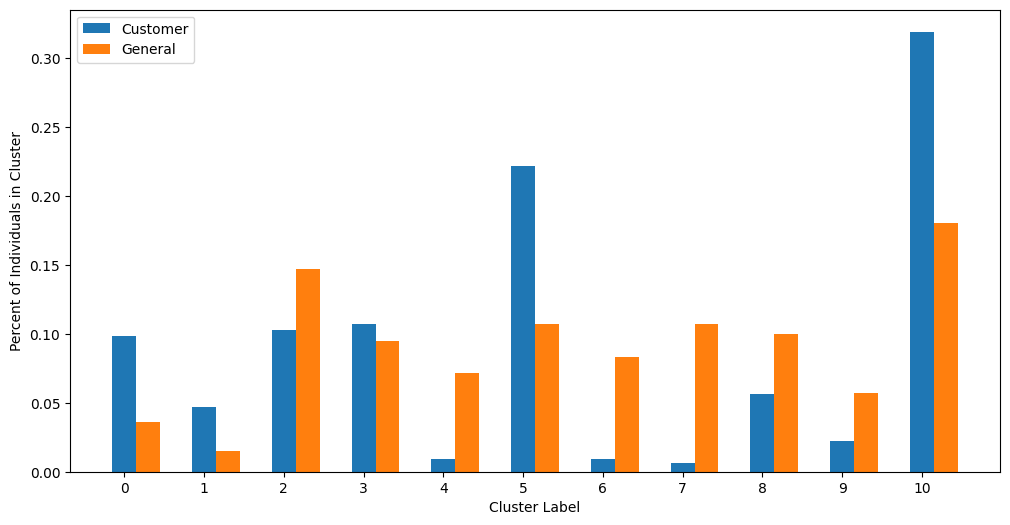

```python
# What kinds of people are part of a cluster that is overrepresented in the
# customer data compared to the general population?
plt.figure(figsize=(12,6))
plt.bar(x=full_df['Label'], height=full_df['Cust_Percent'], width=0.3, label='Customer')
plt.bar(x=full_df['Label'] + 0.3, height=full_df['Gen_Percent'], width=0.3, label='General')
plt.xticks(ticks=full_df['Label'])
plt.xlabel('Cluster Label')
plt.ylabel('Percent of Individuals in Cluster')
plt.legend();
```

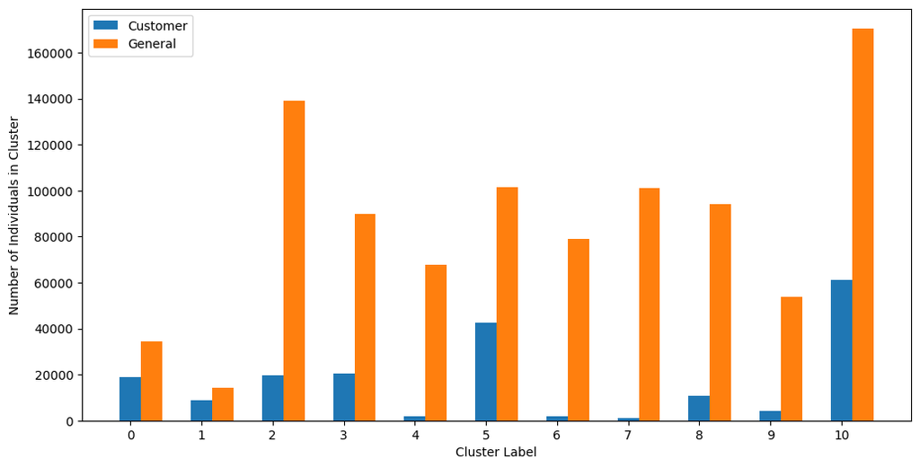

```python
plt.figure(figsize=(12,6))
plt.bar(x=full_df['Label'], height=full_df['Customer'], width=0.3, label='Customer')
plt.bar(x=full_df['Label'] + 0.3, height=full_df['General'], width=0.3, label='General')
plt.xticks(ticks=full_df['Label'])
plt.xlabel('Cluster Label')
plt.ylabel('Number of Individuals in Cluster')
plt.legend();
```

> Comparing the kmeans clusters with the high-null cluster creates a new set in the graph where percentage of customers is higher than the percentage of the general public. This does not, however, affect the most important clusters to look at.

```python
def weigh_clusters(cluster_ind):
    """
    Use cluster label to determine feature importance

    ACCEPTS:
        cluster_ind - Cluster label

    RETURNS:
        top_bot - pandas DataFrame with the top and bottom 5 features for that cluster label
    """
    cluster = general_model.cluster_centers_[cluster_ind]
    scaled_weights = pca.inverse_transform([cluster])

    df = pd.DataFrame({'Weight': scaled_weights.flatten()}, index=customers_clean.columns).sort_values('Weight', ascending=False)
    top_5 = df.head()
    bottom_5 = df.tail()
    top_bot = pd.concat([top_5, bottom_5])
    return top_bot
```

```python
df = weigh_clusters(6)
df
```

|  | Weight |
| --- | --- |
| SEMIO_FAM | 1.347915 |
| SEMIO_KULT | 1.347545 |
| SEMIO_SOZ | 1.185343 |
| SEMIO_REL | 1.130841 |
| FINANZ_SPARER | 1.011481 |
| FINANZ_VORSORGER | -0.933972 |
| SEMIO_KRIT | -0.943144 |
| SEMIO_KAEM | -0.989597 |
| ANREDE_KZ | -1.121867 |
| SEMIO_ERL | -1.254204 |

```python
# Create cluster_labels list; add cluster labels based on relative percent values, two for customers and two for general

cluster_labels = []
for i in range(2):
    cluster_labels.append(int(full_df.sort_values('Cust_Relative_Percent', ascending=False, ignore_index=True)['Label'][i]))
for i in range(2):
    cluster_labels.append(int(full_df.sort_values('Gen_Relative_Percent', ascending=False, ignore_index=True)['Label'][i]))
cluster_labels
```

```
[1, 0, 7, 6]
```

```python
# Create lists to be used for plot settings: title and color
cluster_names = ['Customer_1', 'Customer_2', 'General_1', 'General_2']
colors = ['blue', 'blue', 'orange', 'orange']
```

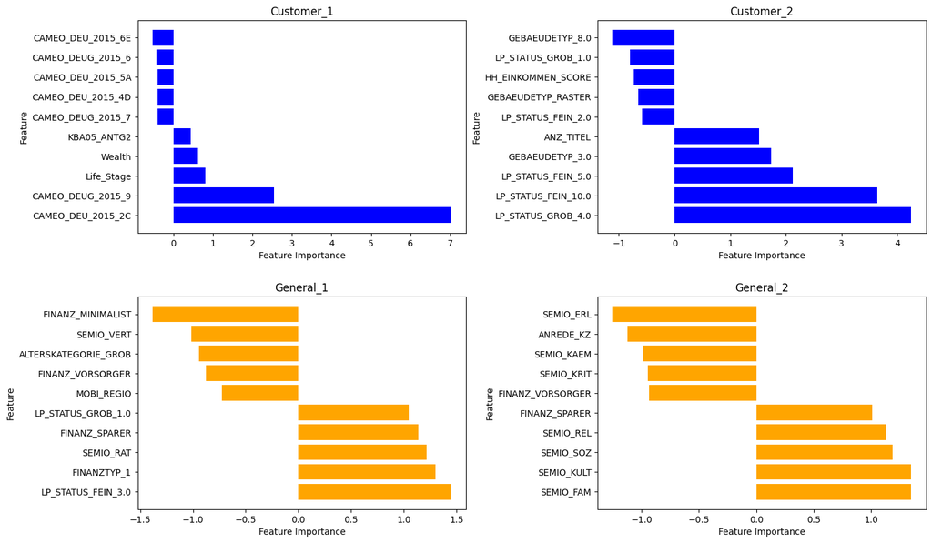

```python
plt.figure(figsize=(16, 10))
for i in cluster_labels:
    df = weigh_clusters(i)
    r = cluster_labels.index(i)

    plt.subplot(2, 2, r+1)

    plt.barh(df.index, df['Weight'], color=colors[r])
    plt.subplots_adjust(wspace=0.4, hspace=0.3)
    plt.xlabel('Feature Importance')
    plt.ylabel('Feature')
    plt.title(cluster_names[r])
```

### Discussion 3.3: Compare Customer Data to Demographics Data

While the first customer cluster does not have many individuals in it, those who are in it are significantly more likely to be a customer than not. Those in the first customer cluster are very likely to be "Established gourmet" (CAMEO_DEU_2015_2C) and urban working class (CAMEO_DEUG_2015_9), and are slightly more likely to have a higher "Wealth" score, which in this database, high Wealth score indicates low wealth, with 1 being wealthy, and 5 being a "poorer household", but whether or not an individual is labeled as "Established gourmet" is the biggest indicator of being in cluster 1, so these individuals will almost always be a safe bet to market to.

Those in Customer_2 are more likely to be minimalistic high-income earners (LP_STATUS_FEIN_5.0) or top earners (LP_STATUS_FEIN_10.0), as well as houseowners (LP_STATUS_GROB_4.0), and unlikely to be "mixed building without actually known company" (GEBAEUDETYP_8.0).

Both general clusters contain positive "FINANZ_SPARER", which was discussed earlier as individuals who are more likely to save money, and negative "FINANZ_VORSORGER", for which the description is simply "be prepared", possibly indicating that these are individuals who like to save money in case they need it, but aren't necessarily frugal. Notably, General_1 contains a positive "LP_STATUS_GROB_1.0", indicating low income earners, while Customer_2 contains a negative "LP_STATUS_GROB_1.0".

Additionally, as seen in cluster 10 (the high-null cluster), it appears that individuals marked as "customers" tend to have less data in the company's system than non-customers.

> Congratulations on making it this far in the project! Before you finish, make sure to check through the entire notebook from top to bottom to make sure that your analysis follows a logical flow and all of your findings are documented in **Discussion** cells. Once you've checked over all of your work, you should export the notebook as an HTML document to submit for evaluation. You can do this from the menu, navigating to **File -> Download as -> HTML (.html)**. You will submit both that document and this notebook for your project submission.